# Ceph

A unified distributed storage system

- High Performance
- High Availiable
- High scalability

# Who is using it

- CERN
- Dreamhost
- jd.com
- kingsoft

# Background

1. Starting at 2006 in Storage Systems Research Center University of California
2. Rbd client merged into linux upstream
3. Best friend of openstack
4. Active community

# Architecture

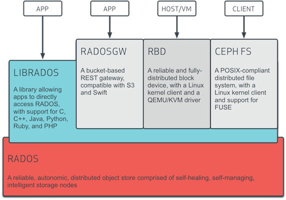

# Architecture

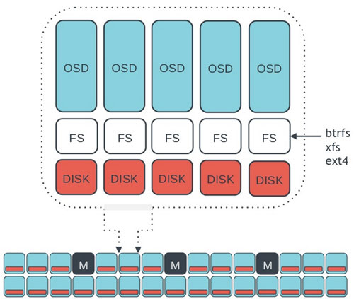

# Architecture: Monitor

Cluster Map

1. Monitor Map, the cluster fsid, the position, name address and port of each monitor
2. OSD Map, a list of pools, replica sizes, PG numbers, a list of OSDs and their status
3. PG Map, the last OSD map epoch, the full ratios, and details on each placement group
4. CRUSH Map, a list of storage devices, the failure domain hierarchy
5. MDS Map, a list of metadata servers

# Architecture

- CRUSH Algorithm:

  CRUSH(CRUSH Map, CRUSH Rules, key, n) = (osd0,osd1 ... osdn)
- Pros:
  1. use *very little* data(CRUSH Map) to compute the postion of replications
  2. CRUSH Map is only changed when adding or removing osd(automatically)

# Client and OSD interact directly

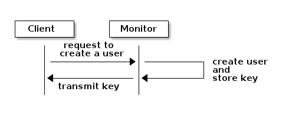

# Client and OSD interact directly

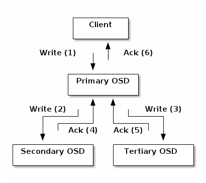

# Mapping PGs to OSDs

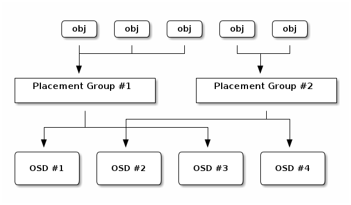

placement group

# Mapping PGs to OSDs

A layer of indirection between the Ceph OSD Daemon and the Ceph Client

- peering
- recovering
- rebalancing

# Rebalancing

- When: Adding or Removing an OSD
- Change crush map
- Migrate PG

# Rebalancing

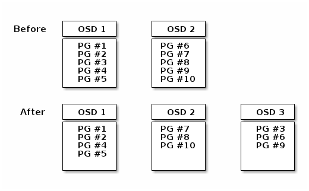

# Smart OSD

- OSDs Check Heartbeats
- OSDs Report Down OSD
- OSDs Report Peering Failur

# Features

1. client和osd直接通信，不需要转发
2. 无单点
3. 强一致性,数据复制
4. 负载均衡,多OSD并发
5. 故障自动检测,自动恢复
6. 容易扩展容量

# CRUSH Map

```
root platter {
        id -5
        alg list
        item ceph-osd-platter-server-1 weight 2.00
        item ceph-osd-platter-server-2 weight 2.00
}
host ceph-osd-platter-server-1 {
        id -3
        alg straw
        item osd.4 weight 1.00
        item osd.5 weight 1.00
}
host ceph-osd-platter-server-2 {
        id -4
        alg straw
        item osd.6 weight 1.00
        item osd.7 weight 1.00
}
```

# CRUSH Map

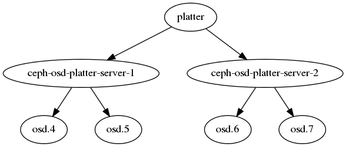

# Simplest CRUSH Algorithm

```
#x:object key
#n:replication number
#t:destnation type
#i:start

select(x="key", n=3, t=osd, i=platter)
O = []
for r <- 1,3 do
    do
      b <- bucket(i)
      o <- b.c(x,r)
      if type(o) != t then
          b = bucket(o)
          retry_bucket <- true
     while(retry_bucket)
     add o to O
end for
return O
```

# CRUSH Bucket Algorithm

```
#parameter : r,x
#return    : number

c(r,x)
```

# CRUSH Bucket Algorithm

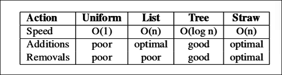

# CRUSH Bucket Algorithm

Uniform

```
#P is based on hash(x)
def c(r,x):
    return (hash(x) + r * P) % m
```

List

```
def c(r,x):
    for i in back tranverse the list
        if hash(r, x, i) < i.weight / previous_weight_sum then
            return i
        endif
    endfor
```

Straw

```
def c(r,x):
    return max([i.weight * hash(r, x, i) for i in each_item])
```

# CRUSH Bucket Algorithm

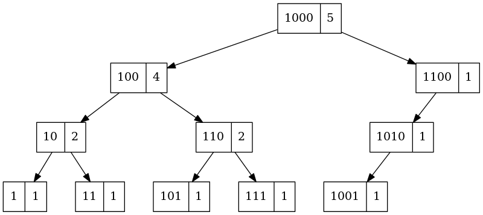

Tree

```
def c(r,x):
    return get_sub(root, r, x)

def get_sub(node, r, x):
    if node is leaf:
        return node
    if hash(x, r, node.index) < node.left.totalWeight:
        return get_sub(node.left, r, x)
    else:
        return get_sub(node.right, r, x)
```

# Librados Prerequires

ceph.conf

```
[global]
mon host = 192.168.1.1
keyring = /etc/ceph/ceph.client.admin.keyring
```

# Librados

Configuring a Cluster Handle

```
#include <rados/librados.h>

rados_t cluster;
rados_create(&cluster, NULL);
rados_conf_read_file(cluster, "/etc/myceph.conf");
```

Writing an Object

```
/* create an "IO context" */
rados_ioctx_t io;
char *poolname = "mypool";
rados_ioctx_create(cluster, poolname, &io);
rados_write_full(io, "greeting", "hello", 5);
```

Cleanup

```
rados_ioctx_destroy(io);
rados_shutdown(cluster);
```

# END

Thank You